# Department of Environment and Natural Resources — Office of the Secretary

The FY 2027 proposed budget in context, FY 2018–2027

September 2026

← All agencies

# Overview

This document tracks the budget of the **Department of Environment and Natural Resources – Office of the Secretary (DENR-OSEC)** across ten fiscal years, FY 2018 to FY 2027 — with **FY 2027 the Executive’s proposal (NEP)**, not yet enacted — following each peso from the Executive’s proposal (NEP) to enactment (GAA), release (allotment), commitment (obligation), and final cash payment (disbursement). It covers the Office of the Secretary; the department’s attached bureaus are summarised in a short section at the end.

It is the long-form companion to the DENR-OSEC briefing material. Where a slide deck must compress, this version keeps the full argument and adds reference tables — sortable, searchable, and exportable — so a reader can interrogate the figures directly.

DENR-OSEC has one defining feature: **its budget has not grown.** Over 2018–2026 it has been held almost perfectly flat in nominal terms at ₱16–19B — which, against the inflation of the period, is a real-terms *cut*. Three further features define it: Congress is a **net subtractor**, trimming the proposal in most years and cutting **forestry** hardest of all; **administration is the single largest line** in the budget; and the department has been **shedding capital spending** (down from 37% of the budget to 12%) in favour of payroll. The result is an environment department doing relatively less on-the-ground work, on a budget that has effectively shrunk, even as its mandate — climate resilience, Manila Bay, biodiversity, mining oversight — has expanded.

# 1 Executive summary

**The FY 2027 proposal (NEP) is ₱20.6B — essentially flat** on the 2026 proposal (₱20.5B), extending a decade of near-zero nominal growth. What makes DENR unusual is that this proposal is closer to a *ceiling* than a floor: **Congress does not reliably augment DENR — it trimmed the 2026 proposal by ₱1.25B at enactment**, so advocates arguing for more cannot assume the enacted budget will rise above the NEP. The proposal barely reshuffles internally — only a handful of lines move by more than ₱0.2B — so the story is the standstill itself, on a budget that has lost roughly 30% of its real value since 2018.

**DENR-OSEC’s budget has been frozen.** The enacted GAA has held at ₱16–20B for nine straight years — ₱19.4B in 2018, ₱19.3B in 2026. **2018 remains the peak.** In nominal terms that is near-zero growth; adjusting for inflation, the FY 2026 budget is worth roughly **₱13.6B in 2018 pesos — about 30% below where the department started the period**.

**Congress is a net subtractor, and forestry is the target.** The enacted GAA came in below the Executive’s proposal in six of nine years. The cuts fall overwhelmingly on **Forest Development** (the greening/reforestation line): cumulatively **−₱12.4B from NEP to GAA**, and the enacted line itself shrank from **₱6.6B (2018) to ₱2.4B (2026)** — a ~63% collapse as the National Greening Program wound down.

**Administration is the single largest line.** General Management and Supervision (₱4.0B in 2026, about **21% of the OSEC budget**) is the biggest single P/A/P — larger than any one operational program.

**The department is shedding capital and adding payroll.** Capital Outlays fell from **37% of the GAA (2018) to 12% (2026)**, while Personnel Services rose from **31% to 45%**. The foreign-assisted field projects (INREMP and the Forestland Management Project) wound down by 2021 and 2023 respectively and were not replaced.

**Court-mandated cleanups are sizable line items.** The Manila Bay rehabilitation (₱1.24B, pursuant to a Supreme Court continuing mandamus) and the Pasig River rehabilitation (₱0.10B) sit inside the operational program.

> DENR is the portrait of a mandate outgrowing its money. The budget has been flat for nearly a decade, Congress keeps cutting the reforestation line, and the department is spending relatively more on salaries and less on the ground — even as climate and environmental pressures intensify.

# 2 A note on the data

**Period.** FY 2018 through FY 2027 for NEP and FY 2018 through FY 2026 for GAA — **FY 2027 is the NEP (the Executive’s proposal) only**, not yet debated or enacted and with no execution data, so wherever a chart or table shows FY 2027 the figure is *proposed*. Unusually for a line department, Congress has *not* reliably added to DENR-OSEC (it trimmed the 2026 proposal), so the FY 2027 NEP is closer to a ceiling than a floor. Execution data (Adjusted Appropriations, Adjusted Allotments, Obligations, Disbursements) is available for every year 2018–2025; FY 2026 reflects NEP/GAA only.

**Scope.** The main analysis is **DENR Office of the Secretary only**; the attached bureaus (EMB, MGB, NAMRIA, NWRB, PCSDS) are summarised in a short **attached-agencies section** at the end. **Current New Appropriations only**; nominal pesos unless a real (2018-constant) figure is named.

**Expense classes.** Personnel Services (PS), Maintenance & Other Operating Expenses (MOOE), and Capital Outlays (CO). DENR carries no Financial Expenses.

**PREXC structure (OSEC).** General Administration and Support; Support to Operations; and three operational programs — **Natural Resources Conservation and Development** (PREXC 3102, the operational core: forestry, protected areas, land survey, coastal/marine, and the Manila Bay and Pasig cleanups), **Natural Resources Enforcement and Permitting** (3101), and a small **Natural Resources Assessment and Research** line (3203).

**On “real terms”.** This dataset contains no price index. The real-terms figures cited here (e.g. the FY 2026 budget at ≈₱13.6B in 2018 pesos, ~30% below 2018) are drawn from the briefing, which deflates by the PSA Consumer Price Index (2018 = 100); the underlying nominal series is reproduced in full here.

**Absorptive-capacity denominator.** Unless noted, ratios use **Adjusted Allotments**. The three ratios are **O/A** (Obligations ÷ Allotment), **D/O** (Disbursements ÷ Obligations), and **D/A** (Disbursements ÷ Allotment).

# 3 The aggregate budget

## 3.1 A flat budget for nine years

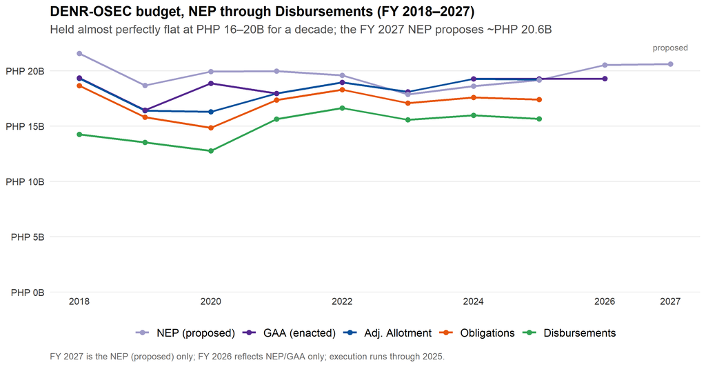

```r
evo <- osec_totals %>% filter(metric %in% c("NEP","GAA","AdjAllot","Obligations","Disbursements")) %>%
  mutate(metric = factor(metric, levels = c("NEP","GAA","AdjAllot","Obligations","Disbursements"),
    labels = c("NEP (proposed)","GAA (enacted)","Adj. Allotment","Obligations","Disbursements")))
ggplot(evo, aes(year, total, color = metric, group = metric)) +
  geom_line(linewidth = 1.0) + geom_point(size = 2) +
  scale_color_manual(values = exec_pal) +
  scale_y_continuous(labels = php_b_axis, breaks = pretty_breaks(6), limits = c(0, NA), expand = expansion(mult = c(0, .05))) +
  scale_x_continuous(breaks = c(seq(2018, 2026, 2), 2027)) +
  annotate("text", x = 2027, y = Inf, label = "proposed", vjust = 1.4, size = 3, color = "grey45") +
  labs(title = "DENR-OSEC budget, NEP through Disbursements (FY 2018–2027)",
       subtitle = "Held almost perfectly flat at PHP 16–20B for a decade; the FY 2027 NEP proposes ~PHP 20.6B",
       x = NULL, y = NULL, caption = "FY 2027 is the NEP (proposed) only; FY 2026 reflects NEP/GAA only; execution runs through 2025.") +
  theme_denr() + guides(color = guide_legend(nrow = 1))
```

```r
tbl_evo <- osec_totals %>% filter(metric %in% c("NEP","GAA","AdjAllot","Obligations","Disbursements")) %>%
  mutate(value = total/1e9) %>% select(year, metric, value) %>%
  pivot_wider(names_from = year, values_from = value) %>%
  mutate(metric = factor(metric, levels = c("NEP","GAA","AdjAllot","Obligations","Disbursements"),
    labels = c("NEP","GAA","Adj. Allotment","Obligations","Disbursements"))) %>%
  arrange(metric) %>% rename(`PHP B` = metric)
kbl_clean(tbl_evo, font = 13, digits = 1, format.args = list(big.mark = ","), na = "")
```

| PHP B | 2018 | 2019 | 2020 | 2021 | 2022 | 2023 | 2024 | 2025 | 2026 | 2027 |
| --- | --- | --- | --- | --- | --- | --- | --- | --- | --- | --- |
| NEP | 21.6 | 18.7 | 19.9 | 20.0 | 19.6 | 17.9 | 18.6 | 19.2 | 20.5 | 20.6 |
| GAA | 19.4 | 16.5 | 18.9 | 18.0 | 19.0 | 18.1 | 19.3 | 19.3 | 19.3 |  |
| Adj. Allotment | 19.3 | 16.4 | 16.3 | 18.0 | 19.0 | 18.1 | 19.3 | 19.2 |  |  |
| Obligations | 18.7 | 15.8 | 14.8 | 17.4 | 18.3 | 17.1 | 17.6 | 17.4 |  |  |
| Disbursements | 14.3 | 13.5 | 12.8 | 15.6 | 16.6 | 15.6 | 16.0 | 15.7 |  |  |

## 3.2 Flat in name, falling in real value

A flat nominal budget understates the squeeze. The index below sets each year’s enacted GAA against 2018 = 100: the nominal line hovers around its starting point the entire period.

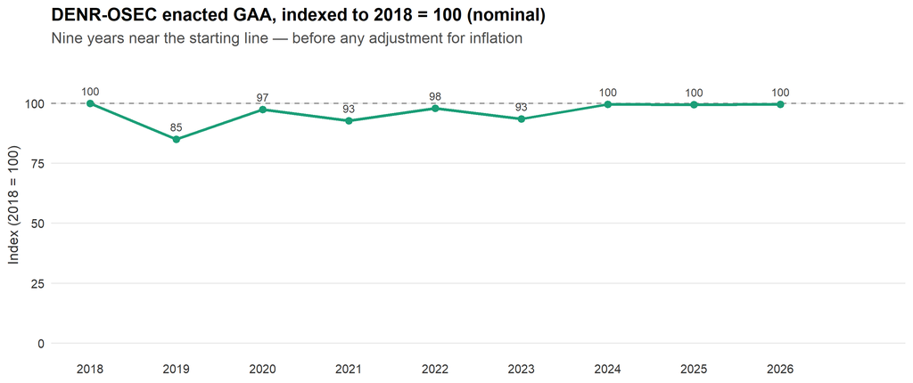

```r
idx <- osec_totals %>% filter(metric == "GAA") %>% arrange(year) %>%
  mutate(index = total / total[year == 2018] * 100)
ggplot(idx, aes(year, index)) +
  geom_hline(yintercept = 100, linetype = "dashed", color = "grey55") +
  geom_line(linewidth = 1.1, color = "#1B9E77") + geom_point(size = 2.2, color = "#1B9E77") +
  geom_text(aes(label = round(index)), vjust = -1.0, size = 3, color = "grey25") +
  scale_x_continuous(breaks = 2018:2026) +
  scale_y_continuous(limits = c(0, 115), breaks = seq(0, 100, 25)) +
  labs(title = "DENR-OSEC enacted GAA, indexed to 2018 = 100 (nominal)",
       subtitle = "Nine years near the starting line — before any adjustment for inflation",
       x = NULL, y = "Index (2018 = 100)") +
  theme_denr()
```

Because the underlying dataset has no price index, the deflated figure here is drawn from the briefing (PSA CPI, 2018 = 100): adjusting for inflation, the FY 2026 budget of ₱19.3B is worth roughly **₱13.6B in 2018 pesos — about 30% below the department’s 2018 level**. The department’s real resources have shrunk by nearly a third even as its mandate has widened.

## 3.3 Congress as a net subtractor

```r
wide_yr <- osec_totals %>% pivot_wider(names_from = metric, values_from = total)
growth <- wide_yr %>% arrange(year) %>%
  transmute(year, `GAA (B)` = round(GAA/1e9,1), `Growth %` = scales::percent(GAA/lag(GAA) - 1, accuracy = 0.1),
            `NEP (B)` = round(NEP/1e9,1), `Net adj. GAA−NEP (B)` = round((GAA-NEP)/1e9,1))
kbl_clean(growth, font = 13, align = "rrrrr", na = "")
```

| year | GAA (B) | Growth % | NEP (B) | Net adj. GAA−NEP (B) |
| --- | --- | --- | --- | --- |
| 2018 | 19.4 |  | 21.6 | -2.2 |
| 2019 | 16.5 | -15.0% | 18.7 | -2.2 |
| 2020 | 18.9 | 14.6% | 19.9 | -1.1 |
| 2021 | 18.0 | -4.8% | 20.0 | -2.0 |
| 2022 | 19.0 | 5.6% | 19.6 | -0.6 |
| 2023 | 18.1 | -4.6% | 17.9 | 0.2 |
| 2024 | 19.3 | 6.6% | 18.6 | 0.7 |
| 2025 | 19.3 | -0.1% | 19.2 | 0.1 |
| 2026 | 19.3 | 0.1% | 20.5 | -1.3 |
| 2027 |  |  | 20.6 |  |

The net-adjustment column is negative in six of nine years. Congress trims the Executive’s environment proposal more often than not — most heavily in 2018–2021 (−₱1B to −₱2.2B a year). As the next sections show, those cuts are concentrated in one place: forestry.

# 4 Where the money goes

## 4.1 By PREXC program

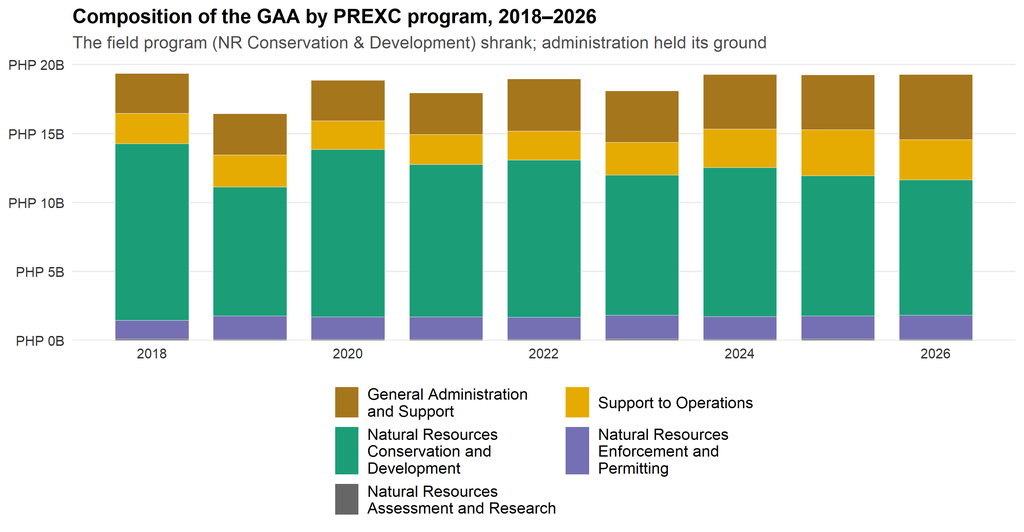

```r
comp <- osec_long %>% filter(metric == "GAA", year <= 2026, !is.na(amount)) %>%
  group_by(year, category) %>% summarise(amount = sum(amount, na.rm = TRUE), .groups = "drop") %>%
  mutate(category = factor(category, levels = names(cat_pal)))
ggplot(comp, aes(year, amount, fill = category)) +
  geom_col(width = 0.75, color = "white", linewidth = 0.2) +
  scale_fill_manual(values = cat_pal, labels = function(x) str_wrap(x, 24)) +
  scale_y_continuous(labels = php_b_axis, breaks = pretty_breaks(6), limits = c(0, NA), expand = expansion(mult = c(0, .05))) +
  scale_x_continuous(breaks = seq(2018, 2026, 2)) +
  labs(title = "Composition of the GAA by PREXC program, 2018–2026",
       subtitle = "The field program (NR Conservation & Development) shrank; administration held its ground",
       x = NULL, y = NULL) +
  theme_denr() + guides(fill = guide_legend(nrow = 3, byrow = TRUE))
```

```r
comp_tbl <- comp %>% group_by(year) %>% mutate(share = round(amount/sum(amount)*100,1)) %>% ungroup() %>%
  select(category, year, share) %>% pivot_wider(names_from = year, values_from = share)
kbl_clean(comp_tbl %>% rename(`Program (% of GAA)` = category), font = 12.5, digits = 1, na = "")
```

| Program (% of GAA) | 2018 | 2019 | 2020 | 2021 | 2022 | 2023 | 2024 | 2025 | 2026 |
| --- | --- | --- | --- | --- | --- | --- | --- | --- | --- |
| General Administration and Support | 14.9 | 18.3 | 15.5 | 16.8 | 19.9 | 20.6 | 20.5 | 20.7 | 24.5 |
| Natural Resources Assessment and Research | 0.5 | 0.4 | 0.4 | 0.4 | 0.4 | 0.4 | 0.3 | 0.5 | 0.4 |
| Natural Resources Conservation and Development | 66.2 | 56.9 | 64.3 | 61.5 | 60.1 | 56.2 | 56.1 | 52.7 | 51.0 |
| Natural Resources Enforcement and Permitting | 7.0 | 10.3 | 8.6 | 9.0 | 8.4 | 9.6 | 8.6 | 8.8 | 9.1 |
| Support to Operations | 11.4 | 14.0 | 11.1 | 12.2 | 11.2 | 13.1 | 14.4 | 17.4 | 15.1 |

## 4.2 By expense class

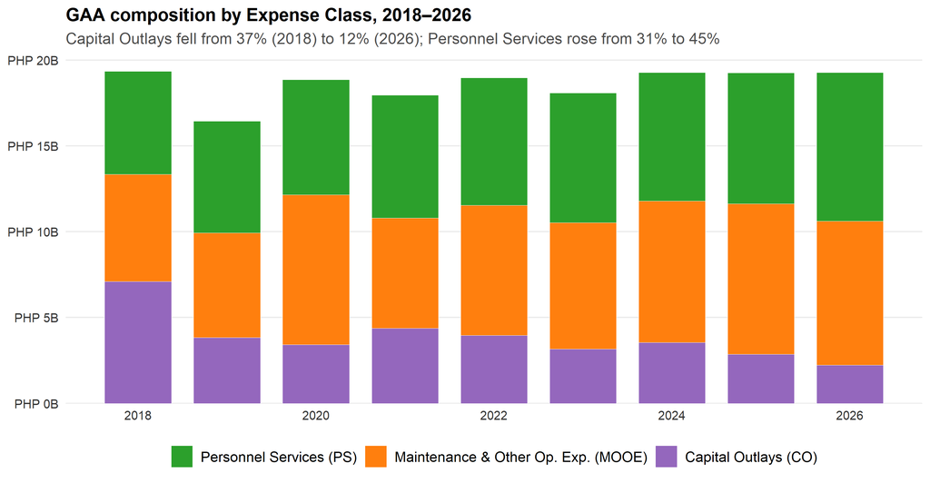

```r
ec_levels <- c("Personnel Services (PS)","Maintenance & Other Op. Exp. (MOOE)","Capital Outlays (CO)")
comp_ec <- df_long_all %>% filter(agency == "Office of the Secretary", metric == "GAA", year <= 2026,
                                  expense_class %in% c("1PS","2MOOE","6CO")) %>%
  group_by(year, expense_class) %>% summarise(amount = sum(amount, na.rm = TRUE), .groups = "drop") %>%
  mutate(expense_class = factor(expense_class, levels = c("1PS","2MOOE","6CO"), labels = ec_levels))
ggplot(comp_ec, aes(year, amount, fill = expense_class)) +
  geom_col(width = 0.75, color = "white", linewidth = 0.2) +
  scale_fill_manual(values = ec_pal) +
  scale_y_continuous(labels = php_b_axis, breaks = pretty_breaks(6), limits = c(0, NA), expand = expansion(mult = c(0, .05))) +
  scale_x_continuous(breaks = seq(2018, 2026, 2)) +
  labs(title = "GAA composition by Expense Class, 2018–2026",
       subtitle = "Capital Outlays fell from 37% (2018) to 12% (2026); Personnel Services rose from 31% to 45%",
       x = NULL, y = NULL) +
  theme_denr() + guides(fill = guide_legend(nrow = 1))
```

```r
ec_share <- comp_ec %>% group_by(year) %>% mutate(share = round(amount/sum(amount)*100,1)) %>% ungroup() %>%
  select(expense_class, year, share) %>% pivot_wider(names_from = year, values_from = share)
kbl_clean(ec_share %>% rename(`Expense class (% of GAA)` = expense_class), font = 12.5, digits = 1, na = "")
```

| Expense class (% of GAA) | 2018 | 2019 | 2020 | 2021 | 2022 | 2023 | 2024 | 2025 | 2026 |
| --- | --- | --- | --- | --- | --- | --- | --- | --- | --- |
| Personnel Services (PS) | 31.1 | 39.7 | 35.5 | 39.8 | 39.2 | 41.8 | 38.9 | 39.7 | 44.9 |
| Maintenance & Other Op. Exp. (MOOE) | 32.2 | 37.1 | 46.3 | 35.8 | 39.9 | 40.7 | 42.7 | 45.5 | 43.5 |
| Capital Outlays (CO) | 36.7 | 23.3 | 18.1 | 24.3 | 20.9 | 17.5 | 18.4 | 14.8 | 11.6 |

## 4.3 The largest P/A/Ps (FY 2027 NEP, proposed)

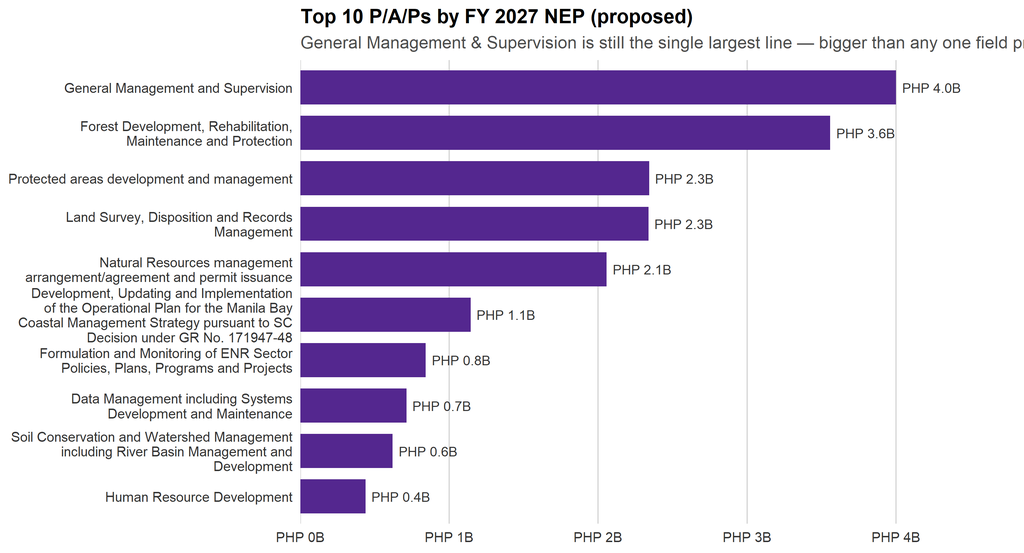

```r
top10 <- osec_pap_year %>% filter(year == 2027, !is.na(NEP), NEP > 0) %>%
  arrange(desc(NEP)) %>% slice_head(n = 10) %>% mutate(pap = factor(pap, levels = rev(pap)))
ggplot(top10, aes(pap, NEP)) +
  geom_col(fill = "#54278F", width = 0.75) +
  geom_text(aes(label = php_b(NEP)), hjust = -0.1, size = 3.3, color = "grey20") +
  coord_flip() +
  scale_x_discrete(labels = function(x) str_wrap(x, 44)) +
  scale_y_continuous(labels = php_b_axis, expand = expansion(mult = c(0, .20)), limits = c(0, NA)) +
  labs(title = "Top 10 P/A/Ps by FY 2027 NEP (proposed)",
       subtitle = "General Management & Supervision is still the single largest line — bigger than any one field program",
       x = NULL, y = NULL) +
  theme_denr() +
  theme(panel.grid.major.y = element_blank(), panel.grid.major.x = element_line(color = "grey85"))
```

That administration tops the list is itself a finding: in a department whose purpose is forests, mines, water, and biodiversity, the single largest line is **General Management and Supervision — ₱4.0B, about 21% of the 2026 OSEC budget**. The operational heavyweights that follow — Forest Development, Protected Areas, Land Survey, and the natural-resources permitting line — are each smaller than the overhead.

### Full P/A/P ranking (interactive)

```r
allp <- osec_pap_year %>% filter(year == 2027) %>%
  transmute(`P/A/P` = pap, `NEP 2027 (B)` = NEP/1e9)
nep_gaa_26 <- osec_pap_year %>% filter(year == 2026) %>%
  transmute(`P/A/P` = pap, `NEP 2026 (B)` = NEP/1e9, `GAA 2026 (B)` = GAA/1e9)
da25 <- osec_pap_year %>% filter(year == 2025) %>%
  transmute(`P/A/P` = pap, `D/A 2025` = ifelse(!is.na(AdjAllot) & AdjAllot > 0, Disbursements/AdjAllot, NA_real_))
allp <- allp %>% full_join(nep_gaa_26, by = "P/A/P") %>% left_join(da25, by = "P/A/P") %>%
  arrange(desc(`NEP 2027 (B)`))
dt_table(allp, page = 12, money_cols = c("NEP 2027 (B)","NEP 2026 (B)","GAA 2026 (B)"), pct_cols = "D/A 2025")
```

| P/A/P | NEP 2027 (B) | NEP 2026 (B) | GAA 2026 (B) | D/A 2025 |
| --- | --- | --- | --- | --- |
| General Management and Supervision | 4.001604 | 4.03374 | 4.03374 | 0.8686512630758971 |
| Forest Development, Rehabilitation, Maintenance and Protection | 3.559213 | 3.508669 | 2.41849 | 0.8875850542129163 |
| Protected areas development and management | 2.343395 | 2.256414 | 2.256414 | 0.826489048585021 |
| Land Survey, Disposition and Records Management | 2.338009 | 2.127443 | 2.127443 | 0.9449744820151187 |
| Natural Resources management arrangement/agreement and permit issuance | 2.057543 | 1.640674 | 1.640674 | 0.869440476448867 |
| Development, Updating and Implementation of the Operational Plan for the Manila Bay Coastal Management Strategy pursuant to SC Decision under GR No. 171947-48 | 1.144526 | 1.239291 | 1.239291 | 0.8936652489447595 |
| Formulation and Monitoring of ENR Sector Policies, Plans, Programs and Projects | 0.84254 | 0.8338 | 0.8338 | 0.9100519664808977 |
| Data Management including Systems Development and Maintenance | 0.713323 | 1.191236 | 0.772702 | 0.3249209739782664 |
| Soil Conservation and Watershed Management including River Basin Management and Development | 0.620246 | 0.743105 | 0.893105 | 0.5914263613664376 |
| Human Resource Development | 0.438704 | 0.43419 | 0.43419 | 0.80243840740213 |

[output cut: 13 more lines]

# 5 What the FY 2027 proposal changes

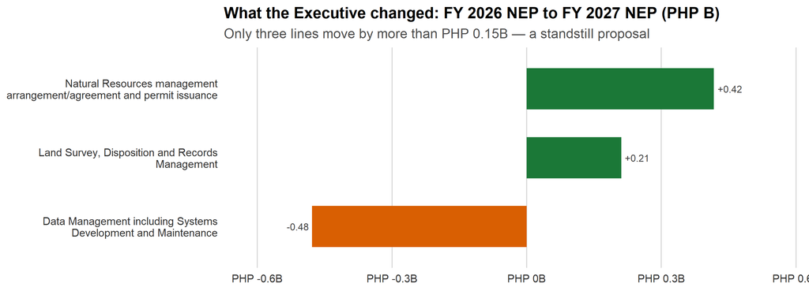

```r
nep_change <- osec_pap_year %>%
  filter(year %in% c(2026, 2027)) %>%
  select(pap, year, NEP) %>%
  pivot_wider(names_from = year, values_from = NEP, names_prefix = "y") %>%
  mutate(change = (coalesce(y2027, 0) - coalesce(y2026, 0)) / 1e9) %>%
  filter(abs(change) >= 0.15) %>%
  arrange(desc(change)) %>%
  mutate(pap = factor(pap, levels = rev(pap)),
         dir = ifelse(change >= 0, "Increased", "Reduced"))

ggplot(nep_change, aes(pap, change, fill = dir)) +
  geom_col(width = 0.6) +
  geom_text(aes(label = sprintf("%+.2f", change),
                hjust = ifelse(change >= 0, -0.15, 1.15)),
            size = 3, color = "grey25") +
  coord_flip() +
  scale_fill_manual(values = c("Increased" = "#1B7837", "Reduced" = "#D95F02")) +
  scale_x_discrete(labels = function(x) str_wrap(x, 44)) +
  scale_y_continuous(labels = function(v) paste0(peso, v, "B"),
                     expand = expansion(mult = c(0.22, 0.22))) +
  labs(title = "What the Executive changed: FY 2026 NEP to FY 2027 NEP (PHP B)",
       subtitle = "Only three lines move by more than PHP 0.15B \u2014 a standstill proposal",
       x = NULL, y = NULL) +
  theme_denr() +
  theme(panel.grid.major.y = element_blank(),
        panel.grid.major.x = element_line(color = "grey85"),
        legend.position = "none")
```

The only material moves are a top-up to **natural-resource management arrangements (+₱0.42B)** and to **land survey (+₱0.21B)**, set against a trim to **data-management and IT systems (−₱0.48B)**. Everything else is held within a rounding error of its 2026 proposed level. For an agency whose mandate — climate resilience, biodiversity, Manila Bay, mining oversight — has only expanded, a proposal that changes essentially nothing is itself the point of scrutiny.